# 6_Conclusiones

## Puntos de corte

Se prueba cambiando punto de corte de 0.5 a 0.3

```r
corte <- 0.3
salida_rf$predcorte <- ifelse(salida_rf$Yes>corte, "Yes", "No")
salida_rf$predcorte <- as.factor(salida_rf$predcorte)
confusionMatrix(salida_rf$obs, salida_rf$predcorte, positive = "Yes")
```

```
## Confusion Matrix and Statistics
##
##           Reference
## Prediction   No  Yes
##        No  1023  139
##        Yes   25  799
##
##                Accuracy : 0.9174
##                  95% CI : (0.9044, 0.9292)
##     No Information Rate : 0.5277
##     P-Value [Acc > NIR] : < 2.2e-16
##
##                   Kappa : 0.8333
##
##  Mcnemar's Test P-Value : < 2.2e-16
##
##             Sensitivity : 0.8518
##             Specificity : 0.9761
##          Pos Pred Value : 0.9697
##          Neg Pred Value : 0.8804
##              Prevalence : 0.4723
##          Detection Rate : 0.4023
##    Detection Prevalence : 0.4149
##       Balanced Accuracy : 0.9140
##
##        'Positive' Class : Yes
##
```

- Solo como experimento adicional, no se observa hay mejora, al contrario, la accuracy desciende de 0.93 a 0.91, pero si ha aumentado la especificidad, se sigue detectando bien los valores negativos.

## Contraste de hipotesis entre algunos modelos

```r
lista_medias <- rbind(medias1,medias2,medias3, medias4, medias5,medias6, medias11,  medias12,medias13, medias14,medias15, medias16)
modelos <- c("xgbm", "randomforest")
contraste <- lista_medias[which(lista_medias$modelo%in%modelos),]
resultados <- t.test(contraste$auc ~contraste$modelo)
resultados
```

```
##
##  Welch Two Sample t-test
##
## data:  contraste$auc by contraste$modelo
## t = -15.115, df = 6.6841, p-value = 2.043e-06
## alternative hypothesis: true difference in means between group randomforest and group xgbm is not equal to 0
## 95 percent confidence interval:
##  -0.013022752 -0.009469958
## sample estimates:
## mean in group randomforest         mean in group xgbm
##                  0.9776175                  0.9888639
```

## Visualpred

Utilizando el script facilitado en los apuntes comparaciones básicas

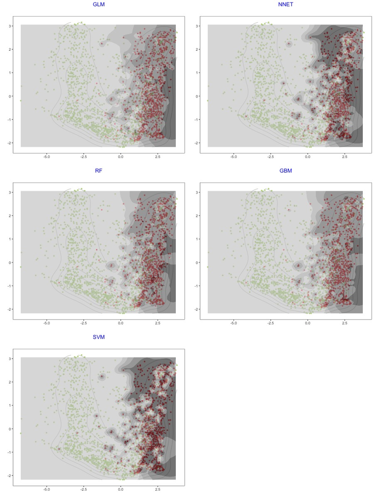

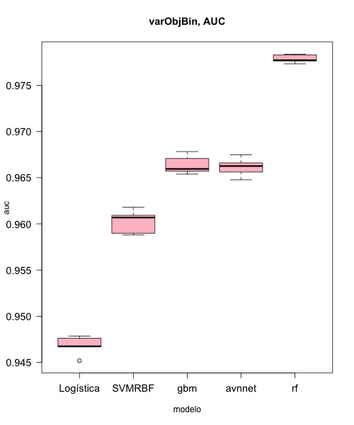

## Tabla resumen

Como punto final a esta practica se adjunta tabla resumen con auc y tasa de fallos para cada modelo evaluado

```r
tabla_final <- lista_medias %>%
  group_by(modelo) %>%
  summarise(tasa=mean(tasa))
knitr::kable(tabla_final, "pipe", caption = "Tasa de fallos ")
```

Tasa de fallos

| modelo | tasa |
| --- | --- |
| Avnnet1 | 0.0734139 |
| Avnnet2 | 0.1138973 |
| Logística1 | 0.1081571 |
| Logística2 | 0.1121853 |
| Red con maxit | 0.0724068 |
| bagging | 0.0726083 |
| gbm | 0.0862034 |
| randomforest | 0.0645519 |
| svmLineal | 0.1072508 |
| svmPoly | 0.0944612 |
| svmRBF | 0.0855992 |
| xgbm | 0.0494461 |

```r
tabla_final <- lista_medias %>%
  group_by(modelo) %>%
  summarise(auc=mean(auc))
knitr::kable(tabla_final, "pipe", caption = "Accuracy ")
```

| modelo | auc |
| --- | --- |
| Avnnet1 | 0.9717350 |
| Avnnet2 | 0.9444342 |
| Logística1 | 0.9468125 |
| Logística2 | 0.9445338 |
| Red con maxit | 0.9722424 |
| bagging | 0.9753555 |
| gbm | 0.9691624 |
| randomforest | 0.9776175 |
| svmLineal | 0.9469829 |
| svmPoly | 0.9573743 |
| svmRBF | 0.9622408 |
| xgbm | 0.9888639 |